# Reproducible Research.Peer-graded Assignment: Course Project 1

Ivano Squiccimarro

2022-03-12

# 1.Introduction

It is now possible to collect a large amount of data about personal movement using activity monitoring devices such as a Fitbit, Nike Fuelband, or Jawbone Up. These type of devices are part of the “quantified self” movement - a group of enthusiasts who take measurements about themselves regularly to improve their health, to find patterns in their behavior, or because they are tech geeks. But these data remain under-utilized both because the raw data are hard to obtain and there is a lack of statistical methods and software for processing and interpreting the data.

This assignment makes use of data from a personal activity monitoring device. This device collects data at 5 minute intervals through out the day. The data consists of two months of data from an anonymous individual collected during the months of October and November, 2012 and include the number of steps taken in 5 minute intervals each day.

# 2.Data Processing

After reading data and loading ggplot package, the date column is transformed in date format.

```r
knitr::opts_chunk$set(echo = TRUE,message = FALSE,warning = FALSE)

file        <- read.csv("C://Users//ivano//Desktop//repdata_data_activity//activity.csv")

library(ggplot2)
file$date   <- as.Date(file$date, format="%Y-%m-%d")
```

## Mean of steps each day

Once the previous step was completed, three vectors are created calculating sum,mean and median of steps within each day and then merged in one single dataframe.

```r
days            <- levels(factor(file$date))
len             <- seq(1,length(days), by=1)

steps       <- c()
sum.of.day      <- c()
mean.of.day     <- c()
median.of.day   <- c()
median      <- c()
mean            <- c()

for (i in len)
{
sum.of.day          <- sum(subset(file, date==days[i])$steps)
mean.of.day         <- mean(subset(file, date==days[i])$steps,na.rm=TRUE)
median.of.day       <- median(as.numeric(levels(factor(subset(file, date==days[i])$steps))),na.rm=TRUE)

steps               <- c(steps,sum.of.day)
mean                <- c(mean,mean.of.day)
median          <- c(median,median.of.day)
}


df      <- as.data.frame(cbind(days,steps,mean,median))
df$steps    <- as.numeric(df$steps)
df$mean     <- as.integer(df$mean)
df$median   <- as.integer(df$median)
df$days     <- as.Date(df$days, format="%Y-%m-%d")

p1 <- ggplot(df) + geom_hline(yintercept = mean(steps, na.rm=TRUE), colour="red")
p1 <- p1         + geom_histogram(aes(x=days,y=steps),bin=length(days),colour="blue", fils="ivory", stat="identity")
p1 <- p1         + ggtitle("Total Steps each day")
```

Here the corresponding table and plot:

```r
head(df)
```

```
##         days steps mean median
## 1 2012-10-01    NA   NA     NA
## 2 2012-10-02   126    0      9
## 3 2012-10-03 11352   39     75
## 4 2012-10-04 12116   42     77
## 5 2012-10-05 13294   46     70
## 6 2012-10-06 15420   53     84
```

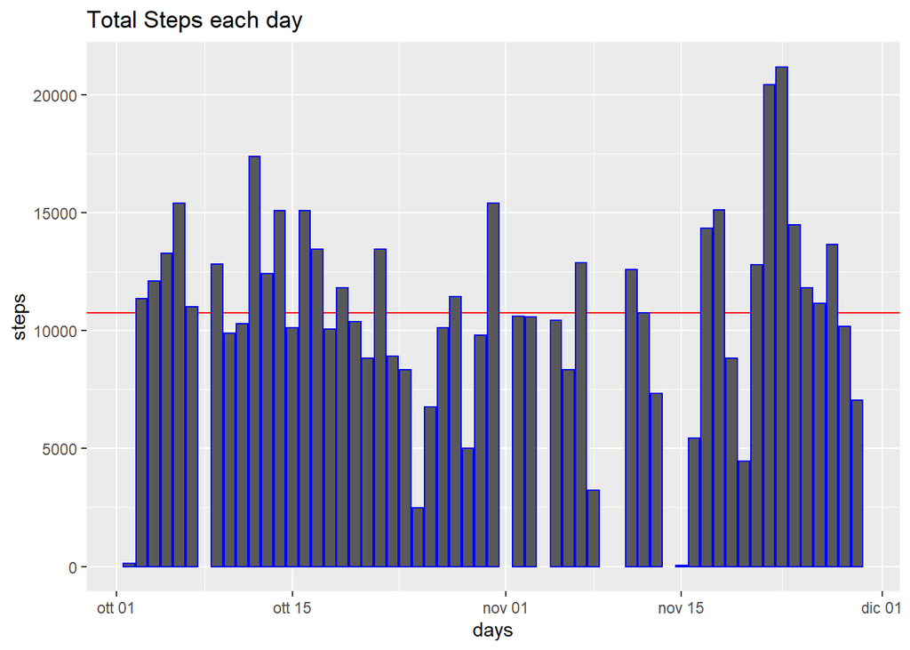

```r
p1
```

## Mean vs Median

After that melting dataframe using days as id the double plot was created in order to compare the median and mean value of steps taken whitin each day:

```r
library(reshape2)

df$steps      <- NULL
new.df      <- melt(df, id.vars="days")
copy.new.df <-new.df

p2      <- ggplot(new.df,aes(days,value))
p2      <- p2 + geom_histogram(aes(x=days,y=value,colour = variable), stat="identity")
p2      <- p2 + ggtitle("Median and Mean Steps each day")
p2      <- p2 + facet_wrap(.~variable) + stat_smooth()
p2      <- p2 + stat_smooth(aes(colour = variable))
```

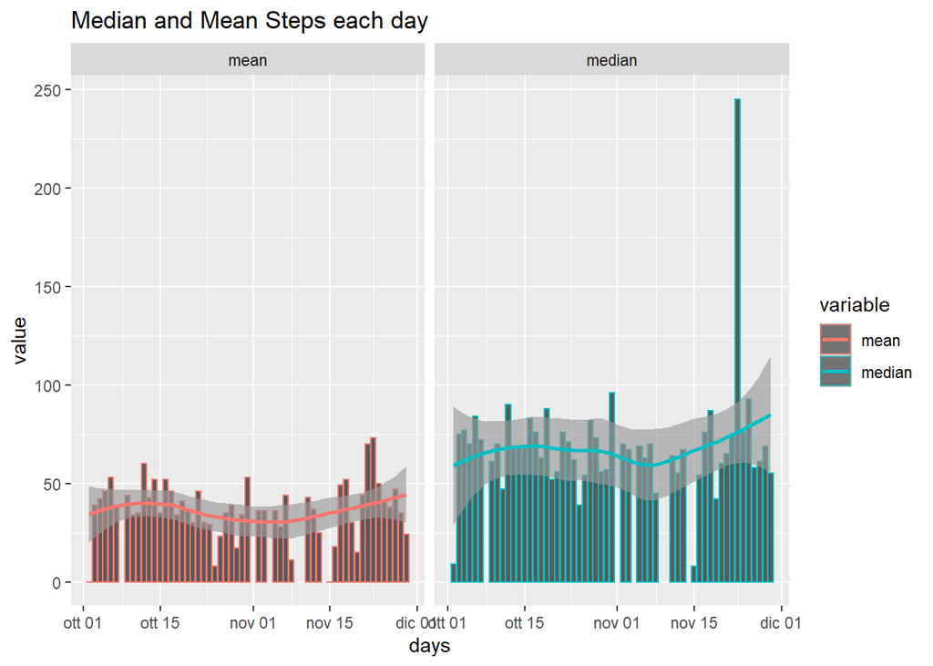

```r
p2
```

## Steps vs Intervals

After that a new dataframe is created subsetting the previous one and making the average steps for each 5 minute interval. Here the corresponding line plot:

```r
interval            <- levels(factor(file$interval))
len                 <- seq(1,length(interval),by=1)
avg.steps           <- c()
mean                <- c()

for(i in len)
{
mean                <- mean(subset(file,interval == interval[i])$steps, na.rm=TRUE)
avg.steps           <- c(avg.steps,mean)

}

df              <- as.data.frame(cbind(avg.steps,interval))
df$interval         <- as.integer(df$interval)
df$avg.steps        <- as.numeric(df$avg.steps)

p3 <- ggplot(data=df,aes(x=interval,y=avg.steps))+ geom_point(colour="red")
p3 <- p3 + geom_line(group=1, colour="blue",alpha=0.5)
p3 <- p3 + ggtitle("Mean of steps made in each interval")
p3 <- p3 + coord_cartesian(ylim=c(0,max(avg.steps)),xlim=c(0,2400))
p3 <- p3 + geom_smooth(method="loess",colour="green")

head(df)
```

```
##   avg.steps interval
## 1 1.7169811        0
## 2 0.3396226        5
## 3 0.1320755       10
## 4 0.1509434       15
## 5 0.0754717       20
## 6 2.0943396       25
```

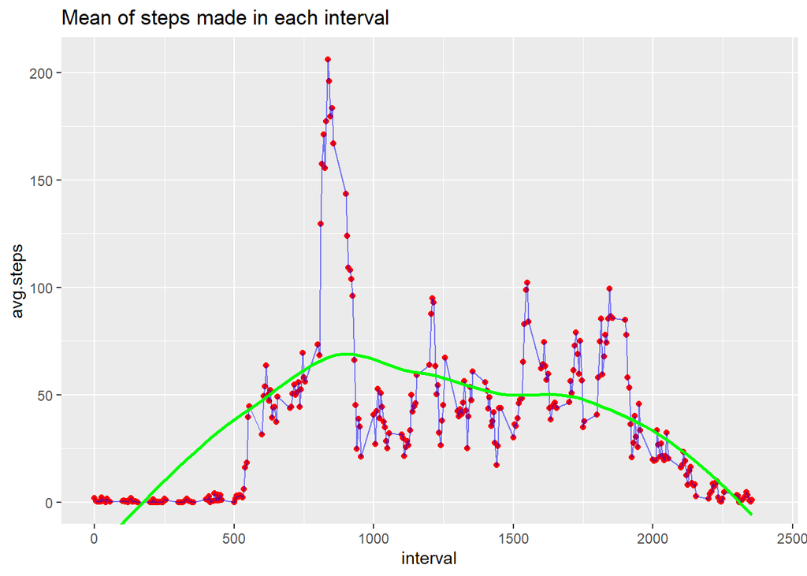

```r
p3
```